# models

Jessica Hunter

4/28/2022

```r
library(tidyverse)
library(here)
library(palmerpenguins)
library(broom)
library(performance)
library(modelsummary)
library(tidymodels)
```

linear model mod<-lm(y~x, data = df)

lm = linear model, y = dependent variable, x = independent variable(s), df = dataframe.

You read this as y is a function of x

Multiple regression mod<-lm(y~x1 + x2, data = df)

Interaction term mod<-lm(y~x1*x2, data = df) the* will compute x1+x2+x1:x2

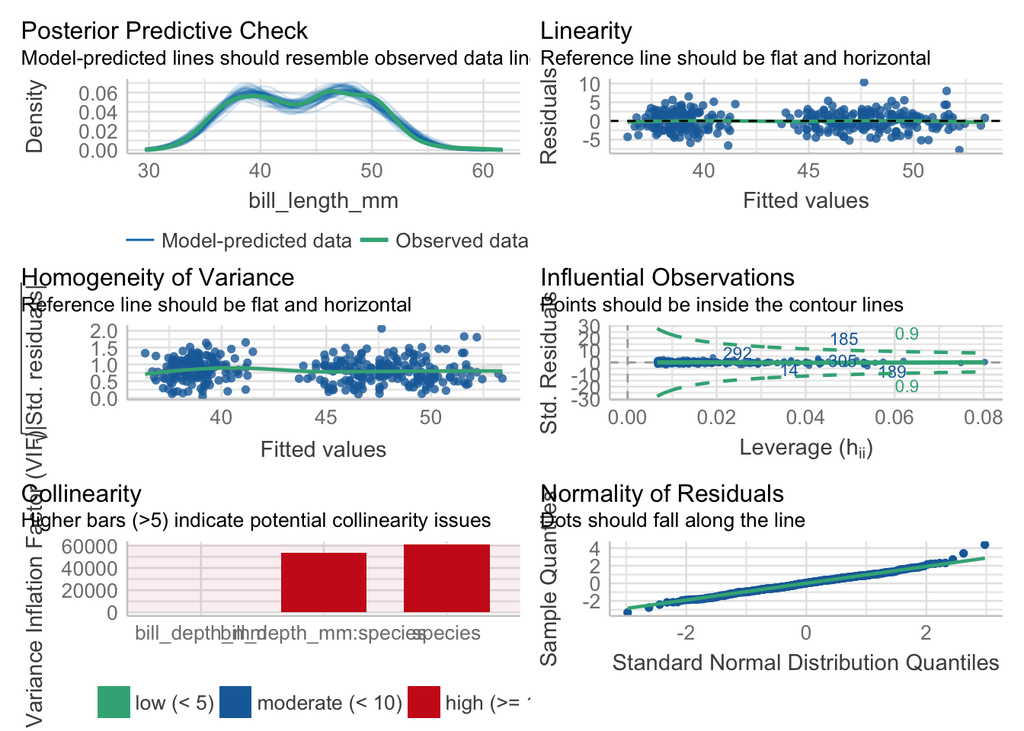

```r
Peng_mod<-lm(bill_length_mm ~ bill_depth_mm*species, data = penguins)
check_model(Peng_mod) # check assumptions of an lm model
```

anova() gives type 3 Anova with capital you can chooses type a or 2

## broom

tidy gives summary coeeficients

~tilda in front of function in map function allows you to change one variable

```r
anova(Peng_mod)
```

```
## Analysis of Variance Table
##
## Response: bill_length_mm
##                        Df Sum Sq Mean Sq F value    Pr(>F)
## bill_depth_mm           1  561.6   561.6  93.965 < 2.2e-16 ***
## species                 2 7460.3  3730.2 624.151 < 2.2e-16 ***
## bill_depth_mm:species   2  134.3    67.1  11.232 1.898e-05 ***
## Residuals             336 2008.1     6.0
## ---
## Signif. codes:  0 '***' 0.001 '**' 0.01 '*' 0.05 '.' 0.1 ' ' 1
```

```r
summary(Peng_mod)
```

```
##
## Call:
## lm(formula = bill_length_mm ~ bill_depth_mm * species, data = penguins)
##
## Residuals:
##     Min      1Q  Median      3Q     Max
## -7.7888 -1.5415  0.0575  1.5873 10.3590
##
## Coefficients:
##                                Estimate Std. Error t value Pr(>|t|)
## (Intercept)                     23.0681     3.0165   7.647 2.18e-13 ***
## bill_depth_mm                    0.8570     0.1641   5.224 3.08e-07 ***
## speciesChinstrap                -9.6402     5.7154  -1.687 0.092590 .
## speciesGentoo                   -5.8386     4.5353  -1.287 0.198850
## bill_depth_mm:speciesChinstrap   1.0651     0.3100   3.435 0.000666 ***
## bill_depth_mm:speciesGentoo      1.1637     0.2789   4.172 3.84e-05 ***
## ---
## Signif. codes:  0 '***' 0.001 '**' 0.01 '*' 0.05 '.' 0.1 ' ' 1
##
## Residual standard error: 2.445 on 336 degrees of freedom
##   (2 observations deleted due to missingness)
## Multiple R-squared:  0.8024, Adjusted R-squared:  0.7995
## F-statistic: 272.9 on 5 and 336 DF,  p-value: < 2.2e-16
```

```r
# Tidy coefficients
coeffs<-tidy(Peng_mod) # just put tidy() around it
knitr::kable(coeffs)
```

| term | estimate | std.error | statistic | p.value |
| --- | --- | --- | --- | --- |
| (Intercept) | 23.0680794 | 3.0165065 | 7.647283 | 0.0000000 |
| bill_depth_mm | 0.8570263 | 0.1640619 | 5.223797 | 0.0000003 |
| speciesChinstrap | -9.6401718 | 5.7154193 | -1.686695 | 0.0925901 |
| speciesGentoo | -5.8385785 | 4.5352593 | -1.287375 | 0.1988497 |
| bill_depth_mm:speciesChinstrap | 1.0650576 | 0.3100169 | 3.435483 | 0.0006657 |
| bill_depth_mm:speciesGentoo | 1.1637417 | 0.2789196 | 4.172320 | 0.0000384 |

```r
#glance extracts R-squared, AICs, etc of the model

# tidy r2, etc
results<-glance(Peng_mod)
knitr::kable(results)
```

| r.squared | adj.r.squared | sigma | statistic | p.value | df | logLik | AIC | BIC | deviance | df.residual | nobs |
| --- | --- | --- | --- | --- | --- | --- | --- | --- | --- | --- | --- |
| 0.8024378 | 0.7994979 | 2.444663 | 272.946 | 0 | 5 | -787.9667 | 1589.933 | 1616.777 | 2008.063 | 336 | 342 |

```r
# augment add residuals and predicted values to your original data and requires that you put both the model and data

# tidy residuals, etc
resid_fitted<-augment(Peng_mod)
knitr::kable(head(resid_fitted))
```

| .rownames | bill_length_mm | bill_depth_mm | species | .fitted | .resid | .hat | .sigma | .cooksd | .std.resid |
| --- | --- | --- | --- | --- | --- | --- | --- | --- | --- |
| 1 | 39.1 | 18.7 | Adelie | 39.09447 | 0.0055284 | 0.0071858 | 2.448309 | 0.0000000 | 0.0022696 |
| 2 | 39.5 | 17.4 | Adelie | 37.98034 | 1.5196627 | 0.0106561 | 2.446886 | 0.0007011 | 0.6249633 |
| 3 | 40.3 | 18.0 | Adelie | 38.49455 | 1.8054469 | 0.0071628 | 2.446307 | 0.0006606 | 0.7411851 |
| 5 | 36.7 | 19.3 | Adelie | 39.60869 | -2.9086874 | 0.0107184 | 2.443090 | 0.0025840 | -1.1962392 |
| 6 | 39.3 | 20.6 | Adelie | 40.72282 | -1.4228216 | 0.0294968 | 2.447037 | 0.0017680 | -0.5907897 |
| 7 | 38.9 | 17.8 | Adelie | 38.32315 | 0.5768521 | 0.0079669 | 2.448105 | 0.0000751 | 0.2369095 |

## Results in modelsummary

{modelsummary} creates tables and plots to summarize statistical models and data in R.

modelsummary includes two families of functions:

Model Summary modelsummary: Regression tables with side-by-side models. modelsummary_wide: Regression tables for categorical response models or grouped coefficients. modelplot: Coefficient plots.

Data Summary datasummary: Powerful tool to create (multi-level) cross-tabs and data summaries. datasummary_balance: Balance tables with subgroup statistics and difference in means (aka “Table 1”). datasummary_correlation: Correlation tables. datasummary_skim: Quick overview (“skim”) of a dataset. datasummary_df: Turn dataframes into nice tables with titles, notes, etc. Export summary tables to word, markdown, or tex document. You can also modify the tables to make them pub quality.

Let’s compare the Peng_mod with one that does not have species as an interaction term.

```r
# New model
Peng_mod_noX<-lm(bill_length_mm ~ bill_depth_mm, data = penguins)
#Make a list of models and name them
models<-list("Model with interaction" = Peng_mod,
             "Model with no interaction" = Peng_mod_noX)
#Save the results as a .docx
modelsummary(models, output = here("week_13","output13","table.docx"))
```

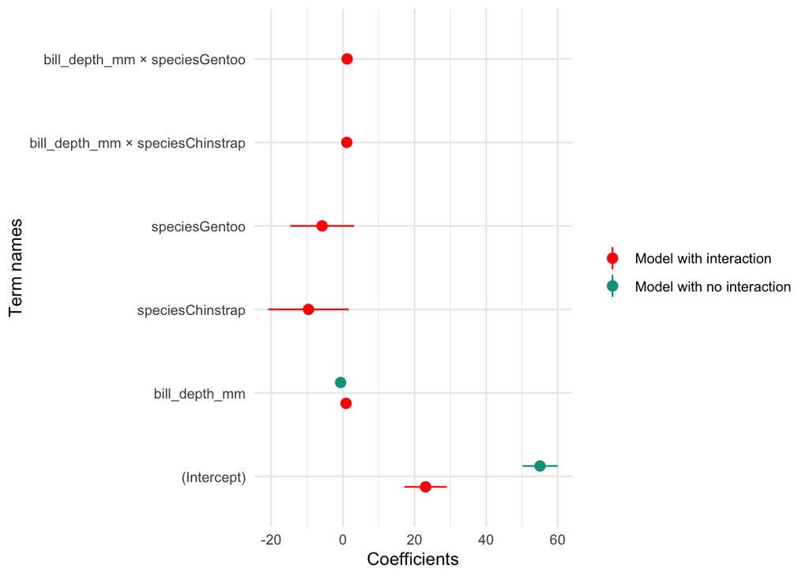

```r
#install.packages("wesanderson")
library(wesanderson)
modelplot(models) +
    labs(x = 'Coefficients',
         y = 'Term names') +
    scale_color_manual(values = wes_palette('Darjeeling1'))
```

Many models with purrr, dplyr, and broom

Let’s say you want to plot and compare lots of different models at the same time and view the results. For example, instead of using species as an interaction term, let’s make an individual model for every species.

We can essentially make a set of lists that have each dataset that we want to model and use the map functions to run the same model to every dataset. We will test it step by step

First, let’s call the penguin data and create a list for the data by each species. We do this using nest(). We are going to nest the data by species.

```r
 models<- penguins %>%
  ungroup()%>% # the penguin data are grouped so we need to ungroup them
    nest(-species) %>%  # nest all the data by species
  mutate(fit = map(data, ~lm(bill_length_mm~body_mass_g, data = .)))
models
```

```
## # A tibble: 3 × 3
##   species   data               fit
##   <fct>     <list>             <list>
## 1 Adelie    <tibble [152 × 7]> <lm>
## 2 Gentoo    <tibble [124 × 7]> <lm>
## 3 Chinstrap <tibble [68 × 7]>  <lm>
```

```r
#View the results.
# First, let's mutate the models list so that we have a tidy coefficient dataframe (using tidy()) and a tidy model results dataframe (using glance())

 results<-models %>%
   mutate(coeffs = map(fit, tidy), # look at the coefficients
          modelresults = map(fit, glance)) %>% # R2 and others
   select(species, coeffs, modelresults) %>% # only keep the results
   unnest() # put it back in a dataframe and specify which columns to unnest

view(results) # view the results
```

## Other very common stats packages

stats: General (lm)and generalized (glm) linear models (already loaded with base R)  
lmer : mixed effects models lmerTest’ : getting results from lmer nlme : non-linear mixed effects models  
mgcv, gam : generalized additive models brms, rstan, and many more : Bayesian modeling  
lavaan, peicewiseSEM : Structural Equation Models rpart, randomForest, xgboost, and more : Machine learning models

## tidymodels

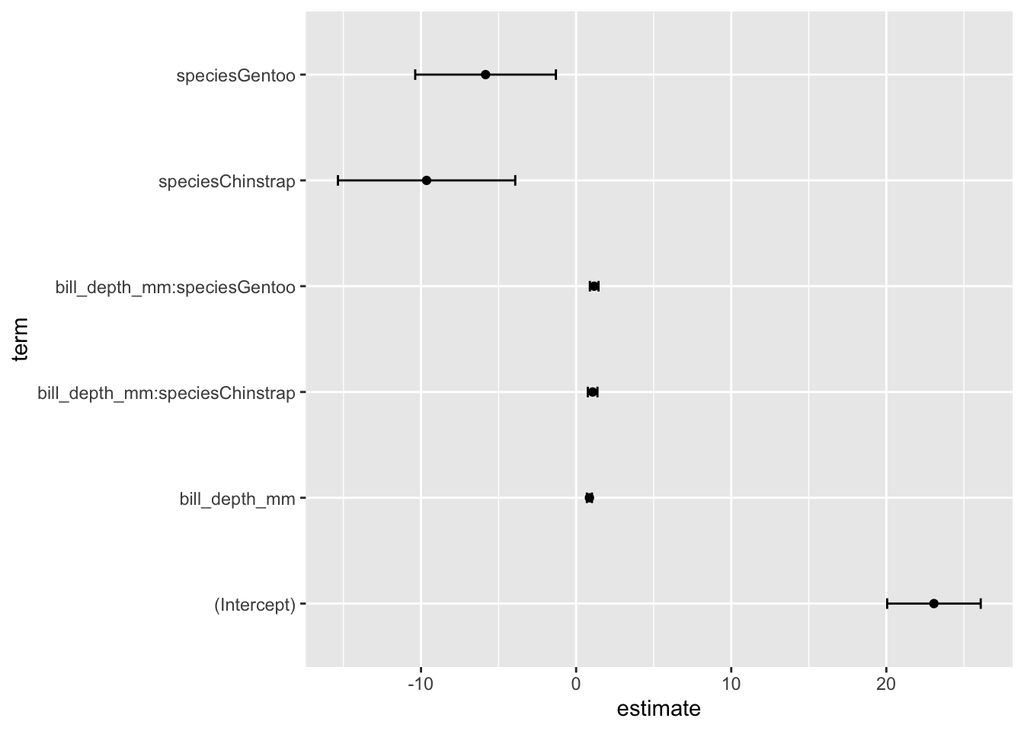

```r
lm_mod<-linear_reg() %>%
  set_engine("lm") %>% # linear model
   fit(bill_length_mm ~ bill_depth_mm*species, data = penguins) %>% # add model fit
  tidy() %>%
    ggplot()+
    geom_point(aes(x = term, y = estimate))+
    geom_errorbar(aes(x = term, ymin = estimate-std.error,
                      ymax = estimate+std.error), width = 0.1 )+
  coord_flip()
lm_mod
```